# MLProject-LANL earthQake prediction Randomforest

Suraj, Akhil

April 19, 2019

## We will use random forest since they are easy to tune and work well with a lot of highly correlated features.

# So let’s start by loading a couple of packages, defining some functions as well as constants that we will use later.

```r
library(data.table)
library(roll)
library(ranger)
library(tidyverse)
```

# ===============================================================

# ===============================================================

# Mean absolute error

```r
mae <- function(y, pred) {
  mean(abs(y - pred))
}
```

# Calculates the coefficient of an AR(1) process z

```r
ar1 <- function(z) {
  cor(z[-length(z)], z[-1])
}
```

# Calculates a buntch of statistics from vector x

```r
univariate_stats <- function(x, tag = NULL, p = c(0, 0.25, 0.75, 1)) {
  x <- x[!is.na(x)]

  out <- c(
    mean = mean(x),
    sd = sd(x),
    setNames(quantile(x, p = p, names = FALSE), paste0("q", p)),
    ar1 = ar1(x))

  if (is.null(tag))
    return(out)

  names(out) <- paste(names(out), tag, sep = "_")
  out
}
```

# Feature extraction on vector x. Basically calls “univariate_stats” on differently transformed x

```r
create_X <- function(x, rolling_windows = c(10, 1000)) {
  stats_full <- univariate_stats(x = x, "full", p = c(0, 1, 5, 10, 25, 50, 75, 90, 95, 99, 100) / 100)
  stats_abs <- univariate_stats(x = abs(x), "abs")

  # Rolling versions of x
  x_mat <- as.matrix(x, ncol = 1)
  roll_sd_k <- lapply(rolling_windows, function(k) roll_sd(x_mat, width = k))

  # Derive stats from rolling versions
  stats_roll_sd <- Map(univariate_stats, roll_sd_k, tag = paste("roll_sd", rolling_windows, sep = "_"))

  c(stats_full, stats_abs, unlist(stats_roll_sd))
}
```

# ===============================================================

# ===============================================================

```r
# Length of test data sets
n_test <- 150000

# By how much do we shift the time window of n_test rows within earthquake?
stride <- 150000

# Positions of earthquakes (see answers in https://www.kaggle.com/c/LANL-Earthquake-Prediction/discussion/77390). Used to create contiguous folds for cross-validation and train/validation split
earthquakes <- c(
    5656573,
   50085877,
  104677355,
  138772452,
  187641819,
  218652629,
  245829584,
  307838916,
  338276286,
  375377847,
  419368879,
  461811622,
  495800224,
  528777114,
  585568143,
  621985672) + 1
```

# Figure out colnames of input as well as number of features

```r
raw <- fread(file.path(".", "Data", "train.csv"), nrows = 150000, data.table = FALSE)
names_input <- names(raw)
names_features <- names(create_X(raw[[1]]))

names_features
```

```
##  [1] "mean_full"          "sd_full"            "q0_full"
##  [4] "q0.01_full"         "q0.05_full"         "q0.1_full"
##  [7] "q0.25_full"         "q0.5_full"          "q0.75_full"
## [10] "q0.9_full"          "q0.95_full"         "q0.99_full"
## [13] "q1_full"            "ar1_full"           "mean_abs"
## [16] "sd_abs"             "q0_abs"             "q0.25_abs"
## [19] "q0.75_abs"          "q1_abs"             "ar1_abs"
## [22] "mean_roll_sd_10"    "sd_roll_sd_10"      "q0_roll_sd_10"
## [25] "q0.25_roll_sd_10"   "q0.75_roll_sd_10"   "q1_roll_sd_10"
## [28] "ar1_roll_sd_10"     "mean_roll_sd_1000"  "sd_roll_sd_1000"
## [31] "q0_roll_sd_1000"    "q0.25_roll_sd_1000" "q0.75_roll_sd_1000"
## [34] "q1_roll_sd_1000"    "ar1_roll_sd_1000"
```

# If not yet created, make directory to save folds

```r
fold_dir <- file.path("strides", stride)
if (!dir.exists(fold_dir)) {
  dir.create(fold_dir, recursive = TRUE)
}
```

## So let’s create one data set per earthquake as follows:

# Load all rows before an earthquake occurs.

# For chunks of size 150’000 (like test data), we extract a couple of features and store them in a row of a matrix X. The response is stored in a vector y.

# We move by “stride” positions and repeat steps 2 & 3 until the earthquake happens.

```r
for (prep_fold in seq_along(earthquakes)) {# prep_fold <- 1
 cat(prep_fold, "\n")

  # Read data between two earthquakes
  raw <- fread(file.path(".", "Data", "train.csv"),
               nrows = c(earthquakes[1], diff(earthquakes))[prep_fold],
               skip = c(0, earthquakes)[prep_fold] + 1)
  setnames(raw, names_input)

  # How many times do we calculate features for this data chunk?
  n_steps <- (nrow(raw) - n_test) %/% stride

  # Init feature matrix and vector of response
  y <- numeric(n_steps)
  X <- matrix(NA, nrow = n_steps, ncol = length(names_features), dimnames = list(NULL, names_features))

  # Loop through chunk and build up y and X
  pb <- txtProgressBar(0, n_steps, style = 3)

  for (i in seq_len(n_steps)) {
    setTxtProgressBar(pb, i)
    from <- 1 + stride * (i - 1)
    to <- n_test + stride * (i - 1)
    X[i, ] <- create_X(raw$acoustic_data[from:to])
    y[i] <- raw$time_to_failure[to]
  }

  save(y, X, file = file.path(fold_dir, paste0("fold_", prep_fold, ".RData")))
}
```

```
## 1
##
##
##
##
##
##
##
##
##
##
##
##
##
##
##
##
```

# Now, the data preparation is over and we can load all saved .RData files to create the full data set. Each .RData (= each earthquake) will serve as one fold in our leave-one-earthquake-out cross-validation strategy.

```r
for (i in seq_along(earthquakes)) {
  load(file.path("strides", stride, paste0("fold_", i, ".RData")))

  fold <- rep(i, length(y))

  if (i == 1) {
    X_mat <- X
    y_vec <- y
    fold_vec <- fold
  } else {
    X_mat <- rbind(X_mat, X)
    y_vec <- c(y_vec, y)
    fold_vec <- c(fold_vec, fold)
  }
}
```

```r
form <- reformulate(colnames(X_mat), "label")
fullDF <- data.frame(label = y_vec, X_mat)
fullDF
```

```
##            label mean_full    sd_full q0_full q0.01_full q0.05_full
## 1     1.43079719  4.884113   5.101106     -98      -8.00      -2.00
## 2     1.39149889  4.725767   6.588824    -154     -11.00      -2.00
## 3     1.35319609  4.906393   6.967397    -106     -15.00      -3.00
## 4     1.31379780  4.902240   6.922305    -199     -12.00      -2.00
## 5     1.27439951  4.908720   7.301110    -126     -15.00      -2.00
## 6     1.23609671  4.913513   5.434111    -144     -10.00      -2.00
## 7     1.19679842  4.855660   5.687823     -78     -12.00      -2.00
## 8     1.15849562  4.505427   5.854512    -134     -11.00      -2.00
## 9     1.11909733  4.717833   7.789643    -156     -16.00      -3.00
## 10    1.07969903  4.730960   6.890459    -126     -14.00      -3.00
## 11    1.04139624  4.582873   6.157272    -115     -11.00      -2.00
## 12    1.00199794  4.329933  15.254000    -478     -25.01      -6.00
## 13    0.96269965  4.464040   8.660502    -169     -19.00      -4.00
## 14    0.92439685  4.680813   6.033346    -129     -12.00      -3.00
```

[output cut: 22210 more lines]

# Now, we will use above mentioned cross-validation strategy to evaluate the quality of our random forest model.

```r
# cross-validation
m_fold <- length(earthquakes)
cv <- numeric(m_fold)
pb <- txtProgressBar(0, m_fold, style = 3)
for (j in seq_along(cv)) { # j <- 1
  j
  setTxtProgressBar(pb, j)
  fit <- ranger(form, fullDF[fold_vec != j, ],num.trees = 500, seed = 3564 + 54 * j, verbose = 2)
  cv[j] <- mae(fullDF[fold_vec == j, "label"], predict(fit, fullDF[fold_vec == j, ])$predictions)
}
```

# Resulting score

```r
mean(cv)
```

```
## [1] 2.26722
```

```r
weighted.mean(cv, w = tabulate(fold_vec, nbins = m_fold))
```

```
## [1] 2.267461
```

```r
# cross-validation
m_fold <- length(earthquakes)
cv <- numeric(m_fold)
pb <- txtProgressBar(0, m_fold, style = 3)
for (j in seq_along(cv)) { # j <- 1
  j
  setTxtProgressBar(pb, j)
  fit <- ranger(form, fullDF[fold_vec != j, ],num.trees = 2000, seed = 3564 + 54 * j, verbose = 2)
  cv[j] <- mae(fullDF[fold_vec == j, "label"], predict(fit, fullDF[fold_vec == j, ])$predictions)
}
```

# Resulting score

```r
mean(cv)
```

```
## [1] 2.265638
```

```r
weighted.mean(cv, w = tabulate(fold_vec, nbins = m_fold))
```

```
## [1] 2.265719
```

```r
# cross-validation
m_fold <- length(earthquakes)
cv <- numeric(m_fold)
pb <- txtProgressBar(0, m_fold, style = 3)
for (j in seq_along(cv)) { # j <- 1
  j
  setTxtProgressBar(pb, j)
  fit <- ranger(form, fullDF[fold_vec != j, ],num.trees = 5000, seed = 3564 + 54 * j, verbose = 2)
  cv[j] <- mae(fullDF[fold_vec == j, "label"], predict(fit, fullDF[fold_vec == j, ])$predictions)
}
```

# Resulting score

```r
mean(cv)
```

```
## [1] 2.264714
```

```r
weighted.mean(cv, w = tabulate(fold_vec, nbins = m_fold))
```

```
## [1] 2.264752
```

# retrain on full data for submission

```r
fit_rf <- ranger(form, fullDF, importance = "impurity", seed = 345)
fit_rf
```

```
## Ranger result
##
## Call:
##  ranger(form, fullDF, importance = "impurity", seed = 345)
##
## Type:                             Regression
## Number of trees:                  500
## Sample size:                      4121
## Number of independent variables:  35
## Mtry:                             5
## Target node size:                 5
## Variable importance mode:         impurity
## Splitrule:                        variance
## OOB prediction error (MSE):       6.87198
## R squared (OOB):                  0.4809372
```

# Variable importance

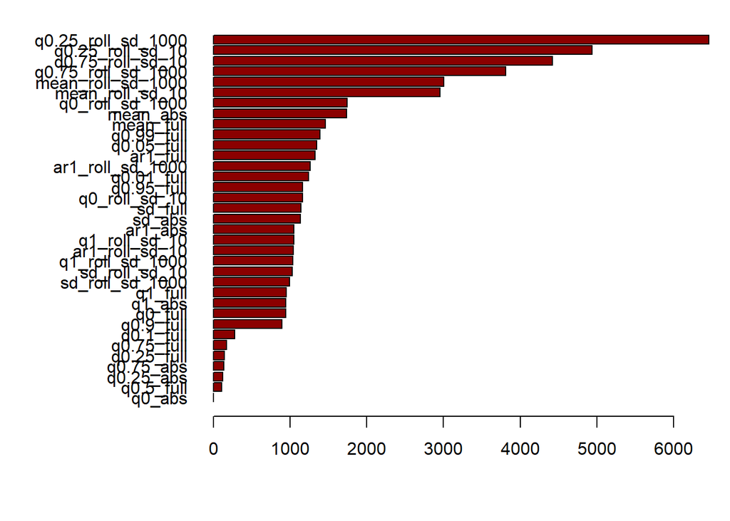

```r
par(mar = c(5, 10, 1, 1))
barplot(importance(fit_rf) %>% sort %>% tail(70), horiz = T, las = 1,col = "darkred",beside = TRUE)
```

```r
# submission
submission <- fread(file.path(".", "Data", "sample_submission.csv"))

# Load each test data and create the feature matrix. Takes 2-3 minutes and can be skipped
# if playing with strides (and not with features)
load_and_prepare <- function(file) {
  seg <- fread(file.path(".", "Data", "test", paste0(file, ".csv")))
  create_X(seg$acoustic_data)
}
all_test <- lapply(submission$seg_id, load_and_prepare)
all_test2 <- do.call(rbind, all_test)
save(all_test2, file = "test_prep.RData")
# load("test_prep.RData")
dim(all_test2) # 2624   35
```

```
## [1] 2624   35
```

```r
submission$time_to_failure <- predict(fit_rf, data.frame(all_test2))$prediction

head(submission)
```

```
##        seg_id time_to_failure
## 1: seg_00030f        3.371948
## 2: seg_0012b5        5.935122
## 3: seg_00184e        5.407245
## 4: seg_003339        8.219858
## 5: seg_0042cc        6.424599
## 6: seg_004314        2.880581
```

```r
# Save
fwrite(submission, paste0("submission_rf_stride_", stride, ".csv"))
```

Changing the strides to 75000 and checking for 500 trees, 2000 trees, 5000 trees

```r
# By how much do we shift the time window of n_test rows within earthquake?
stride <- 75000
```

```r
# If not yet created, make directory to save folds
fold_dir <- file.path("strides", stride)
if (!dir.exists(fold_dir)) {
  dir.create(fold_dir, recursive = TRUE)
}

for (prep_fold in seq_along(earthquakes)) {# prep_fold <- 1
 cat(prep_fold, "\n")

  # Read data between two earthquakes
  raw <- fread(file.path(".", "Data", "train.csv"),
               nrows = c(earthquakes[1], diff(earthquakes))[prep_fold],
               skip = c(0, earthquakes)[prep_fold] + 1)
  setnames(raw, names_input)

  # How many times do we calculate features for this data chunk?
  n_steps <- (nrow(raw) - n_test) %/% stride

  # Init feature matrix and vector of response
  y <- numeric(n_steps)
  X <- matrix(NA, nrow = n_steps, ncol = length(names_features), dimnames = list(NULL, names_features))

  # Loop through chunk and build up y and X
  pb <- txtProgressBar(0, n_steps, style = 3)

  for (i in seq_len(n_steps)) {
    setTxtProgressBar(pb, i)
    from <- 1 + stride * (i - 1)
    to <- n_test + stride * (i - 1)
    X[i, ] <- create_X(raw$acoustic_data[from:to])
    y[i] <- raw$time_to_failure[to]
  }

  save(y, X, file = file.path(fold_dir, paste0("fold_", prep_fold, ".RData")))
}
```

```
## 1
##
##
##
##
##
##
##
##
##
##
##
##
##
##
##
##
```

```r
for (i in seq_along(earthquakes)) {
  load(file.path("strides", stride, paste0("fold_", i, ".RData")))

  fold <- rep(i, length(y))

  if (i == 1) {
    X_mat <- X
    y_vec <- y
    fold_vec <- fold
  } else {
    X_mat <- rbind(X_mat, X)
    y_vec <- c(y_vec, y)
    fold_vec <- c(fold_vec, fold)
  }
}
```

```r
form <- reformulate(colnames(X_mat), "label")
fullDF <- data.frame(label = y_vec, X_mat)
```

```r
# cross-validation
m_fold <- length(earthquakes)
m_fold
```

```
## [1] 16
```

```r
cv <- numeric(m_fold)
cv
```

```
##  [1] 0 0 0 0 0 0 0 0 0 0 0 0 0 0 0 0
```

```r
#pb <- txtProgressBar(0, m_fold, style = 3)

for (j in seq_along(cv)) { # j <- 1
  #setTxtProgressBar(pb, j)
  fit <- ranger(form, fullDF[fold_vec != j, ],num.trees = 500, seed = 3564 + 54 * j, verbose = 2)
  cv[j] <- mae(fullDF[fold_vec == j, "label"], predict(fit, fullDF[fold_vec == j, ])$predictions)
}
```

```r
# Resulting score
mean(cv)
```

```
## [1] 2.282808
```

```r
weighted.mean(cv, w = tabulate(fold_vec, nbins = m_fold))
```

```
## [1] 2.282839
```

```r
# cross-validation
m_fold <- length(earthquakes)
m_fold
```

```
## [1] 16
```

```r
cv <- numeric(m_fold)
cv
```

```
##  [1] 0 0 0 0 0 0 0 0 0 0 0 0 0 0 0 0
```

```r
pb <- txtProgressBar(0, m_fold, style = 3)
for (j in seq_along(cv)) { # j <- 1
  setTxtProgressBar(pb, j)
  fit <- ranger(form, fullDF[fold_vec != j, ],num.trees = 2000, seed = 3564 + 54 * j, verbose = 2)
  cv[j] <- mae(fullDF[fold_vec == j, "label"], predict(fit, fullDF[fold_vec == j, ])$predictions)
}
# Resulting score
mean(cv)
```

```
## [1] 2.28191
```

```r
weighted.mean(cv, w = tabulate(fold_vec, nbins = m_fold))
```

```
## [1] 2.282194
```

```r
# cross-validation
m_fold <- length(earthquakes)
m_fold
```

```
## [1] 16
```

```r
cv <- numeric(m_fold)

pb <- txtProgressBar(0, m_fold, style = 3)
for (j in seq_along(cv)) { # j <- 1
  setTxtProgressBar(pb, j)
  fit <- ranger(form, fullDF[fold_vec != j, ],num.trees = 5000, seed = 3564 + 54 * j, verbose = 2)
  cv[j] <- mae(fullDF[fold_vec == j, "label"], predict(fit, fullDF[fold_vec == j, ])$predictions)
}
# Resulting score
mean(cv)
```

```
## [1] 2.28231
```

```r
weighted.mean(cv, w = tabulate(fold_vec, nbins = m_fold))
```

```
## [1] 2.282426
```

Changing the strides to 50000 and checking for 500 trees, 2000 trees, 5000 trees

```r
# By how much do we shift the time window of n_test rows within earthquake?
stride <- 50000
```

```r
# If not yet created, make directory to save folds
fold_dir <- file.path("strides", stride)
if (!dir.exists(fold_dir)) {
  dir.create(fold_dir, recursive = TRUE)
}

for (prep_fold in seq_along(earthquakes)) {# prep_fold <- 1
 cat(prep_fold, "\n")

  # Read data between two earthquakes
  raw <- fread(file.path(".", "Data", "train.csv"),
               nrows = c(earthquakes[1], diff(earthquakes))[prep_fold],
               skip = c(0, earthquakes)[prep_fold] + 1)
  setnames(raw, names_input)

  # How many times do we calculate features for this data chunk?
  n_steps <- (nrow(raw) - n_test) %/% stride

  # Init feature matrix and vector of response
  y <- numeric(n_steps)
  X <- matrix(NA, nrow = n_steps, ncol = length(names_features), dimnames = list(NULL, names_features))

  # Loop through chunk and build up y and X
  pb <- txtProgressBar(0, n_steps, style = 3)

  for (i in seq_len(n_steps)) {
    setTxtProgressBar(pb, i)
    from <- 1 + stride * (i - 1)
    to <- n_test + stride * (i - 1)
    X[i, ] <- create_X(raw$acoustic_data[from:to])
    y[i] <- raw$time_to_failure[to]
  }

  save(y, X, file = file.path(fold_dir, paste0("fold_", prep_fold, ".RData")))
}
```

```
## 1
##
##
##
##
##
##
##
##
##
##
##
##
##
##
##
##
```

```r
for (i in seq_along(earthquakes)) {
  load(file.path("strides", stride, paste0("fold_", i, ".RData")))

  fold <- rep(i, length(y))

  if (i == 1) {
    X_mat <- X
    y_vec <- y
    fold_vec <- fold
  } else {
    X_mat <- rbind(X_mat, X)
    y_vec <- c(y_vec, y)
    fold_vec <- c(fold_vec, fold)
  }
}
```

```r
form <- reformulate(colnames(X_mat), "label")
fullDF <- data.frame(label = y_vec, X_mat)
```

```r
# cross-validation
m_fold <- length(earthquakes)
m_fold
```

```
## [1] 16
```

```r
cv <- numeric(m_fold)
cv
```

```
##  [1] 0 0 0 0 0 0 0 0 0 0 0 0 0 0 0 0
```

```r
#pb <- txtProgressBar(0, m_fold, style = 3)

for (j in seq_along(cv)) { # j <- 1
  #setTxtProgressBar(pb, j)
  fit <- ranger(form, fullDF[fold_vec != j, ],num.trees = 500, seed = 3564 + 54 * j, verbose = 2)
  cv[j] <- mae(fullDF[fold_vec == j, "label"], predict(fit, fullDF[fold_vec == j, ])$predictions)
}
```

```r
# Resulting score
mean(cv)
```

```
## [1] 2.284206
```

```r
weighted.mean(cv, w = tabulate(fold_vec, nbins = m_fold))
```

```
## [1] 2.284351
```

```r
# cross-validation
m_fold <- length(earthquakes)
m_fold
```

```
## [1] 16
```

```r
cv <- numeric(m_fold)
cv
```

```
##  [1] 0 0 0 0 0 0 0 0 0 0 0 0 0 0 0 0
```

```r
pb <- txtProgressBar(0, m_fold, style = 3)
for (j in seq_along(cv)) { # j <- 1
  setTxtProgressBar(pb, j)
  fit <- ranger(form, fullDF[fold_vec != j, ],num.trees = 2000, seed = 3564 + 54 * j, verbose = 2)
  cv[j] <- mae(fullDF[fold_vec == j, "label"], predict(fit, fullDF[fold_vec == j, ])$predictions)
}
# Resulting score
mean(cv)
```

```
## [1] 2.281801
```

```r
weighted.mean(cv, w = tabulate(fold_vec, nbins = m_fold))
```

```
## [1] 2.282518
```

```r
# cross-validation
m_fold <- length(earthquakes)
m_fold
```

```
## [1] 16
```

```r
cv <- numeric(m_fold)

pb <- txtProgressBar(0, m_fold, style = 3)
for (j in seq_along(cv)) { # j <- 1
  setTxtProgressBar(pb, j)
  fit <- ranger(form, fullDF[fold_vec != j, ],num.trees = 5000, seed = 3564 + 54 * j, verbose = 2)
  cv[j] <- mae(fullDF[fold_vec == j, "label"], predict(fit, fullDF[fold_vec == j, ])$predictions)
}
# Resulting score
mean(cv)
```

```
## [1] 2.281677
```

```r
weighted.mean(cv, w = tabulate(fold_vec, nbins = m_fold))
```

```
## [1] 2.282003
```

Changing the strides to 30000 and checking for 500 trees, 2000 trees, 5000 trees

```r
# By how much do we shift the time window of n_test rows within earthquake?
stride <- 30000
```

```r
# If not yet created, make directory to save folds
fold_dir <- file.path("strides", stride)
if (!dir.exists(fold_dir)) {
  dir.create(fold_dir, recursive = TRUE)
}

for (prep_fold in seq_along(earthquakes)) {# prep_fold <- 1
 cat(prep_fold, "\n")

  # Read data between two earthquakes
  raw <- fread(file.path(".", "Data", "train.csv"),
               nrows = c(earthquakes[1], diff(earthquakes))[prep_fold],
               skip = c(0, earthquakes)[prep_fold] + 1)
  setnames(raw, names_input)

  # How many times do we calculate features for this data chunk?
  n_steps <- (nrow(raw) - n_test) %/% stride

  # Init feature matrix and vector of response
  y <- numeric(n_steps)
  X <- matrix(NA, nrow = n_steps, ncol = length(names_features), dimnames = list(NULL, names_features))

  # Loop through chunk and build up y and X
  pb <- txtProgressBar(0, n_steps, style = 3)

  for (i in seq_len(n_steps)) {
    setTxtProgressBar(pb, i)
    from <- 1 + stride * (i - 1)
    to <- n_test + stride * (i - 1)
    X[i, ] <- create_X(raw$acoustic_data[from:to])
    y[i] <- raw$time_to_failure[to]
  }

  save(y, X, file = file.path(fold_dir, paste0("fold_", prep_fold, ".RData")))
}
```

```
## 1
##
##
##
##
##
##
##
##
##
##
##
##
##
##
##
##
```

```r
for (i in seq_along(earthquakes)) {
  load(file.path("strides", stride, paste0("fold_", i, ".RData")))

  fold <- rep(i, length(y))

  if (i == 1) {
    X_mat <- X
    y_vec <- y
    fold_vec <- fold
  } else {
    X_mat <- rbind(X_mat, X)
    y_vec <- c(y_vec, y)
    fold_vec <- c(fold_vec, fold)
  }
}
```

```r
form <- reformulate(colnames(X_mat), "label")
fullDF <- data.frame(label = y_vec, X_mat)
```

```r
# cross-validation
m_fold <- length(earthquakes)
m_fold
```

```
## [1] 16
```

```r
cv <- numeric(m_fold)
cv
```

```
##  [1] 0 0 0 0 0 0 0 0 0 0 0 0 0 0 0 0
```

```r
#pb <- txtProgressBar(0, m_fold, style = 3)

for (j in seq_along(cv)) { # j <- 1

  setTxtProgressBar(pb, j)
  fit <- ranger(form, fullDF[fold_vec != j, ],num.trees = 500, seed = 3564 + 54 * j, verbose = 2)
  cv[j] <- mae(fullDF[fold_vec == j, "label"], predict(fit, fullDF[fold_vec == j, ])$predictions)
}
# Resulting score
mean(cv)
```

```
## [1] 2.294254
```

```r
weighted.mean(cv, w = tabulate(fold_vec, nbins = m_fold))
```

```
## [1] 2.2918
```

```r
# cross-validation
m_fold <- length(earthquakes)
m_fold
```

```
## [1] 16
```

```r
cv <- numeric(m_fold)
cv
```

```
##  [1] 0 0 0 0 0 0 0 0 0 0 0 0 0 0 0 0
```

```r
pb <- txtProgressBar(0, m_fold, style = 3)
for (j in seq_along(cv)) { # j <- 1
  setTxtProgressBar(pb, j)
  fit <- ranger(form, fullDF[fold_vec != j, ],num.trees = 2000, seed = 3564 + 54 * j, verbose = 2)
  cv[j] <- mae(fullDF[fold_vec == j, "label"], predict(fit, fullDF[fold_vec == j, ])$predictions)
}
# Resulting score
mean(cv)
```

```
## [1] 2.291627
```

```r
weighted.mean(cv, w = tabulate(fold_vec, nbins = m_fold))
```

```
## [1] 2.289706
```

```r
# cross-validation
m_fold <- length(earthquakes)
m_fold
```

```
## [1] 16
```

```r
cv <- numeric(m_fold)

pb <- txtProgressBar(0, m_fold, style = 3)
for (j in seq_along(cv)) { # j <- 1
  setTxtProgressBar(pb, j)
  fit <- ranger(form, fullDF[fold_vec != j, ],num.trees = 5000, seed = 3564 + 54 * j, verbose = 2)
  cv[j] <- mae(fullDF[fold_vec == j, "label"], predict(fit, fullDF[fold_vec == j, ])$predictions)
}
# Resulting score
mean(cv)
```

```
## [1] 2.291568
```

```r
weighted.mean(cv, w = tabulate(fold_vec, nbins = m_fold))
```

```
## [1] 2.289344
```

```r
# submission
submission <- fread(file.path(".", "Data", "sample_submission.csv"))

# Load each test data and create the feature matrix. Takes 2-3 minutes and can be skipped
# if playing with strides (and not with features)
load_and_prepare <- function(file) {
  seg <- fread(file.path(".", "Data", "test", paste0(file, ".csv")))
  create_X(seg$acoustic_data)
}
all_test <- lapply(submission$seg_id, load_and_prepare)
all_test2 <- do.call(rbind, all_test)
save(all_test2, file = "test_prep.RData")
# load("test_prep.RData")
dim(all_test2) # 2624   35
```

```
## [1] 2624   35
```

```r
submission$time_to_failure <- predict(fit_rf, data.frame(all_test2))$prediction

head(submission)
```

```
##        seg_id time_to_failure
## 1: seg_00030f        3.371948
## 2: seg_0012b5        5.935122
## 3: seg_00184e        5.407245
## 4: seg_003339        8.219858
## 5: seg_0042cc        6.424599
## 6: seg_004314        2.880581
```

```r
# Save
fwrite(submission, paste0("submission_rf_stride_", stride, ".csv"))
```